# Case Study: MovieMagic Concessions and User Review Statistical Analysis

Brian Burdick, Chris Gearheart and Chris Porter

## Introduction

*MovieMagic*, is a regional movie chain operating in the Southwest region of the US. They are considering ways in which they can increase spending on concessions. MovieMagic has collected information about 2000 of its customers, some of whom are part of their loyalty program and some who are not. They have information on 8 variables, which they plan to use as predictors. They plan to use the amount spent on concessions as the outcome variable since they have learned from observation that much of their profit is derived from concession sales.

**Regression Analysis**

```r
model1<- lm(amount_spent~., data=data)
summary(model1) # will give output for each level of each categorical predictor
```

```
##
## Call:
## lm(formula = amount_spent ~ ., data = data)
##
## Residuals:
##     Min      1Q  Median      3Q     Max
## -27.758  -6.907  -0.469   6.353  33.108
##
## Coefficients:
##                      Estimate Std. Error t value Pr(>|t|)
## (Intercept)         7.2904823  1.7460659   4.175 3.10e-05 ***
## age                 0.1909459  0.0258699   7.381 2.30e-13 ***
## jobentrepreneur    -0.9951303  1.4593219  -0.682  0.49537
## jobfreelance       -0.9680464  1.5290773  -0.633  0.52675
## jobhospitality     -4.3037172  2.2164135  -1.942  0.05231 .
## jobindustrial       0.3617043  0.7519594   0.481  0.63056
## jobmanagement      -0.3125959  1.0038267  -0.311  0.75553
## jobmedical         -0.1478728  0.8713087  -0.170  0.86525
## jobretired          1.2151574  1.4386754   0.845  0.39842
## jobself-employed    2.6769520  1.5610047   1.715  0.08652 .
## jobstudent          1.5190723  1.9840665   0.766  0.44398
## jobtechnician      -0.1151806  0.8480546  -0.136  0.89198
## jobunknown          1.9898514  4.0480811   0.492  0.62309
## streaming          -0.8549315  0.2086322  -4.098 4.34e-05 ***
## educationsecondary -0.1321160  0.6216084  -0.213  0.83171
## educationtertiary   0.0495287  0.9093088   0.054  0.95657
## educationunknown   -1.1056419  1.0253676  -1.078  0.28104
## seen_aloneyes       1.4887933  1.4624027   1.018  0.30878
## discountyes        -0.6911536  0.7089804  -0.975  0.32975
## days_member         0.0499474  0.0008925  55.962  < 2e-16 ***
## movies_seen         0.5157587  0.1619800   3.184  0.00147 **
## ---
## Signif. codes:  0 '***' 0.001 '**' 0.01 '*' 0.05 '.' 0.1 ' ' 1
##
## Residual standard error: 9.662 on 1979 degrees of freedom
## Multiple R-squared:  0.6378, Adjusted R-squared:  0.6341
## F-statistic: 174.2 on 20 and 1979 DF,  p-value: < 2.2e-16
```

Q1 Of the 8 predictors, which predictors have a significant influence on amount spent on concessions? Which predictors are multicollinear? Justify your response with reasons from the analysis.

*Multicollinear Analysis*

The primary test for mulitcollinearity is to calculate the Variance Inflation Factor (VIF) for each independent variable.

```r
vif(model1)
```

```
##                 GVIF Df GVIF^(1/(2*Df))
## age         1.192316  1        1.091932
## job         2.551815 11        1.043502
## streaming   1.040355  1        1.019978
## education   2.296708  3        1.148641
## seen_alone  1.007720  1        1.003852
## discount    1.028988  1        1.014390
## days_member 1.060568  1        1.029839
## movies_seen 1.065285  1        1.032127
```

None of the variables display a high degree of multicollinearity (VIF > 5). As such, no measures are required to address multicollinearity in the model.

Q2 Which predictors have a positive influence and which predictors have a negative influence on the amount spent on concessions? Which analysis, regression or penalized regression, helped you answer this question? If you ran a neural net model, can it help you find the significant (or not) predictors and their magnitude and direction of influence on the outcome?

Of the significant independent variables, *age*, *days_member* and *movies_seen* all display a positive influence on the outcome variable *amount_spent* meaning that for every increase in these variables, it is predicted that the amount spent on concession will also increase. The only significant predictor variable to display a negative influence is *streaming* which shows a remarkably strong negative influence when compared with the other predictor variables. Therefore any increase in this variable will strongly decrease the *amount_spent* outcome variable. This was determined using a linear regression. Based upon the low levels of multicollinearity observed above, penalized regression would not yield significantly different results. Use of a neural net model would give us weights, but due to the characteristics of a neural net model, we would no be able to determine the direction or magnitude of any independent variables effect.

## Strategies to increase concessions spending

The statistically significant variables and their direction are `age` (higher age means higher sales), quantity of `streaming` subscriptions held by customer (more subscriptions means lower sales), `days member` (veteran MovieMagic members spend more on concessions), and `movies_seen` during the last time period (more movies seen correlates to higher sales).

These variables suggest a demographic story about MovieMagic’s most profitable customers. The chain’s cash cows are likely middle-aged or senior movie buffs who have, for whatever reason, not imitated young consumers’ tendency to join multiple on-demand media platforms despite the wider movie selection the platforms offer. These customers also enjoy MovieMagic’s concessions enough that their consumption engenders more consumption — something about the concessions brings the customers back again and again as their membership matures.

In light of this information, management will win by optimizing its concessions portfolio, delivery and marketing to defensively retain these big-spending customers. It could offer concessions popular among older consumers, consider movie-themed product tie-ins in light of the segments’ love for cinema, and create on-site advertising about its concessions with testimonials from satisfied long-term members to incentivize new members to try concessions early in their membership. Management should not rule out the use of deeply discounted coupons to encourage new members to try the concessions right after joining. Although our initial regression on the full data set shows that `discount:yes` has a negative effect on concession sales, that result was not statistically significant. Further experimentation could prove that a coupon for the right product(s), with the right amount of discount, or delivered at a convenient moment (offered proactively at the point-of-sale versus by email or post) increases spending.

**Offensively**, management can entice new customers by digitally advertising to middle-aged or senior consumers who are known movie buffs on Facebook — a platform whose users skew older. Additionally, management can opt **not** to advertise to leads who “like” or follow popular shows that are available exclusively on Netflix, Hulu or other streaming platforms, assuming that if they like several of those shows, the customers may have subscriptions to multiple streaming platforms.

### Penalized Regression Analysis

One way to address multicollinearity (if we had detected it in our model) would be to use a penalized regression.

Penalized regressions add a regularization parameter to their coefficients if two or more predictors appear to be multicollinear while the algorithm regresses all predictors against each other. In that case, the **regressions carefully add errors or bias to their coefficients, assuming the tweaks will decrease variance when the regression applied to future samples**.

Glmnet’s application of the Lasso regression is a powerful penalized regression tool and an optimal choice for variable selection. In contrast with a Ridge regression, which can penalize or tweak coefficients without fully declaring them statistically irrelevant, **the Lasso regression can set irrelevant predictors to zero and extract meaning from any remaining predictors**, however subtle their influence.

```r
outcome <- data$amount_spent
predictors <- data.matrix(data[,c(1:8)])

# Create a Lasso model on all 2,000 observations in the original data set
lasso_model <- cv.glmnet(x = predictors,
                         y = outcome,
                         alpha = 1,
                         standardize = TRUE,
                         nfolds = 4,
                         type.measure = "default")


# The coefficients of a Lasso regression on our dataset.
(lassm1 <- coef(lasso_model, s="lambda.min", exact=FALSE))
```

```
## 9 x 1 sparse Matrix of class "dgCMatrix"
##                      s1
## (Intercept)  7.04994145
## age          0.17430899
## job          .
## streaming   -0.62892807
## education   -0.02193835
## seen_alone   0.26973992
## discount    -0.16001273
## days_member  0.04927198
## movies_seen  0.40225582
```

### Avoid Overfitting with Test/Train Cross-Validation

Using any predictive model risks developing a regression with a laser-precise fit to a research sample that performs poorly when used on a fresh sample from the population being studied. Analysts walk a tightrope between bias and variance — how much precision should be sacrificed in the interest of generalizability to future samples from the population?

One way to mitigate that risk is to simulate the transition from the training sample to a new sample from the population by pretending that a minority percentage of our observations **are** a new sample. We call that percentage of observations a “test,” “validation” or “hold-out” set. The remaining observations are called the “train” set because they’re used to train our algorithm.

We answer the question of how much precision to sacrifice in the interest of generalizibility by making our test set larger or smaller by percentage until we find the model with optimal RMSE and R-squared values.

In the case of MovieMagic, we will cross-validate our findings by comparing a **80% train / 20% test** and a **70% train / 30% test** set.

```r
set.seed(1234)

# Create the 70/30 train and test sets
sample7 <- sample.split(data$amount_spent, SplitRatio = 0.7)
train7 <- subset(data, sample7 == TRUE)
test7 <- subset(data, sample7 == FALSE)

# Create the 80/20 train and test sets
sample8 <- sample.split(data$amount_spent, SplitRatio = 0.8)
train8 <- subset(data, sample8 == TRUE)
test8 <- subset(data, sample8 == FALSE)
```

```r
# Create a Lasso regression on the 80/20 training set
lasso_model8 <- cv.glmnet(x = data.matrix(train8[,c(1:8)]),
                         y = train8$amount_spent,
                         alpha = 1,
                         standardize = TRUE,
                         nfolds = 4,
                         type.measure = "default")


# Lasso coefficients of 80% training set
(lass8coef <- coef(lasso_model8, s="lambda.min", exact=FALSE))
```

```
## 9 x 1 sparse Matrix of class "dgCMatrix"
##                      s1
## (Intercept)  6.75326231
## age          0.18280792
## job          .
## streaming   -0.71148233
## education   -0.14185655
## seen_alone   1.27840808
## discount    -0.57955048
## days_member  0.04987201
## movies_seen  0.52694265
```

```r
# Create a Lasso regression on the 70/30 training set
lasso_model7 <- cv.glmnet(x = data.matrix(train7[,c(1:8)]),
                         y = train7$amount_spent,
                         alpha = 1,
                         standardize = TRUE,
                         nfolds = 4,
                         type.measure = "default")


# Lasso coefficients of 70% training set
(lass7coef <- coef(lasso_model7, s="lambda.min", exact=FALSE))
```

```
## 9 x 1 sparse Matrix of class "dgCMatrix"
##                      s1
## (Intercept)  7.17712886
## age          0.17084982
## job          .
## streaming   -0.44319315
## education    .
## seen_alone   0.15319969
## discount    -0.29097990
## days_member  0.04786677
## movies_seen  0.36371297
```

```r
# Create a Lasso model based on the 70/30 training set
model7 <- train(amount_spent ~ ., data = train7, method = "lasso", na.action=na.exclude)
predictions7 <-predict(model7, newdata=test7)

# Create a Lasso model based on the 80/20 training set
model8 <- train(amount_spent ~ ., data = train8, method = "lasso", na.action=na.exclude)
predictions8 <-predict(model8, newdata=test8)


# 70/30 split - RMSE, Rsquared, and MAE values
postResample(predictions7, test7$amount_spent)
```

```
##      RMSE  Rsquared       MAE
## 10.044226  0.669543  8.035391
```

```r
# 80/20 split - RMSE, Rsquared, and MAE values
postResample(predictions8, test8$amount_spent)
```

```
##      RMSE  Rsquared       MAE
## 8.9948022 0.6759327 7.2603958
```

**Text Analysis**

Question 6 MovieMagic wants to visualize the reviews through a wordcloud and wants to find out which words are used most commonly in the reviews that customers write for MovieMagic. Create 2 wordclouds - one for reviews that received 3, 4, or 5 star ratings and another with reviews that received 1 or 2 stars ratings. Knowing the prominent words in each of the wordclouds, what strategies can be developed in messaging customers? Would the strategies differ?

Answer: “The strategies will differ greatly because the negative group is damage control messaging and the positive group is reminding them of why they loved going to the movie.

Positive Reviews The three most common words are Great, Movie, and Food. Based on the top three most common words customers enjoyed the movies and food that was offered. A few strategies that we would suggest focusing on are. Communication around new movies coming out and seasonal concession treats with images. Ideally if name and card information could be tied to what they purchased at the concession stand maybe a bogo could be offered to this group. We would also like to conduct additional analysis to see what messaging is more effective i.e. new movie + concession bogo, new movie, new movie + discounted popcorn etc. We would want to get this dialed in to see which is more effective.

Negative Reviews The three most common words are Hour, Food, and Like. Based on the word cloud the service was slow and took around an hour to get their food. The negative reviews sound like they need internal strategies more than external ones. Perhaps the theater concessions are under staffed, poorly organized, or has inefficient processes. This could be focus area for the theaters manager to improve for their customers. A time study could be completed on various nights to see the length of time it takes for people to get their food. Once that number has been improved messaging to this group could be around the improvements in the speed of service. ”

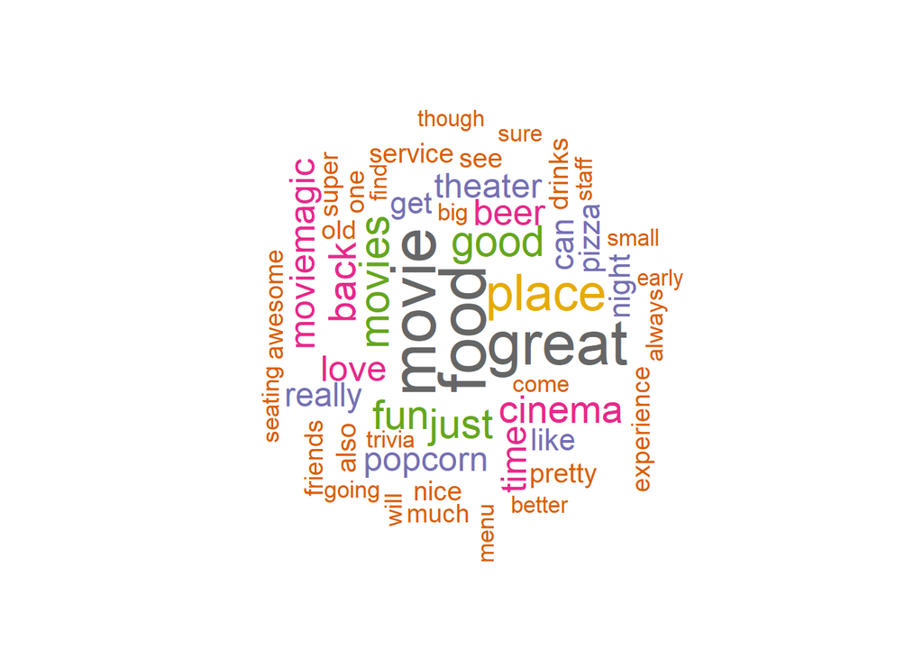

```r
reviews <- read.csv(url("http://data.mishra.us/files/project_reviews.csv"))

#Positive Word Cloud

Positive_Reviews <- filter(reviews,star >= 3)

Review_corpus_p <- VCorpus(VectorSource(Positive_Reviews$text))

Review_corpus_p <- tm_map(Review_corpus_p, content_transformer(tolower)) # covert all to lower case else same word as lower and uppercase will classified as different
Review_corpus_p <- tm_map(Review_corpus_p, removeWords, stopwords(kind="en")) # remove stop words
func_Space <- content_transformer(function(x, pattern) gsub(pattern, " ", x)) # a function to clean /,@,\\,|
Review_corpus_p <- tm_map(Review_corpus_p, func_Space, "/|@|\\|")
Review_corpus_p <- tm_map(Review_corpus_p, stripWhitespace) # remove white space
Review_corpus_p <- tm_map(Review_corpus_p, removeNumbers) # remove numeric values
Review_corpus_p <- tm_map(Review_corpus_p, removePunctuation) # remove punctuations

dtm_review <- TermDocumentMatrix(Review_corpus_p)

m <- as.matrix(dtm_review)
v <- sort(rowSums(m),decreasing=TRUE)
review_final <- data.frame(word = names(v),freq=v)

set.seed(1234)
wordcloud(words = review_final$word, freq = review_final$freq, min.freq = 2,
          max.words=50, random.order=FALSE, rot.per=0.35,
          colors=brewer.pal(8, "Dark2"),scale=c(3, 0.7))
```

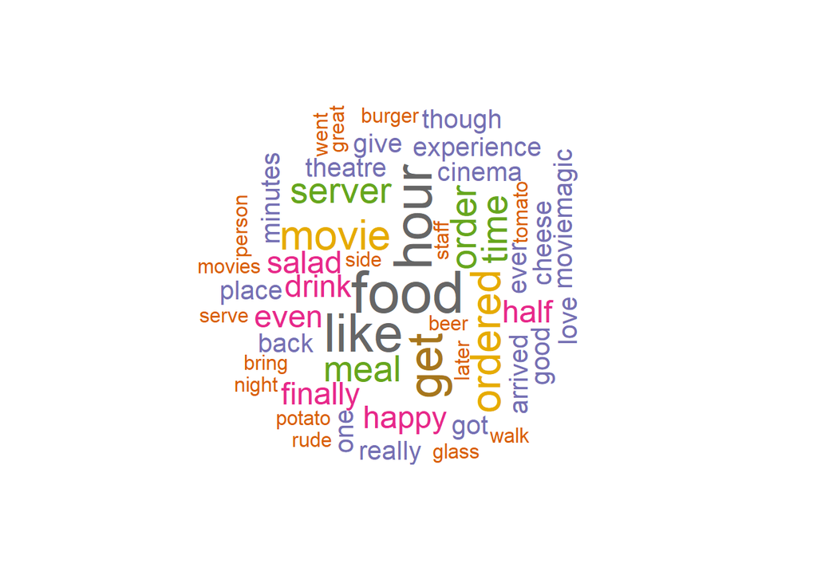

```r
##Negative Word Cloud

Negative_Reviews <- filter(reviews,star < 3)

Review_corpus_n <- VCorpus(VectorSource(Negative_Reviews$text))

Review_corpus_n <- tm_map(Review_corpus_n, content_transformer(tolower)) # covert all to lower case else same word as lower and uppercase will classified as different

Review_corpus_n <- tm_map(Review_corpus_n, removeWords, stopwords(kind="en")) # if we remove stopwords the wordcloud becomes sparse.
# Run with and without stop words to see how word cloud changes

func_Space <- content_transformer(function(x, pattern) gsub(pattern, " ", x)) # a function to clean /,@,\\,|
Review_corpus_n <- tm_map(Review_corpus_n, func_Space, "/|@|\\|")
Review_corpus_n <- tm_map(Review_corpus_n, stripWhitespace) # remove white space
Review_corpus_n <- tm_map(Review_corpus_n, removeNumbers) # remove numbers
Review_corpus_n <- tm_map(Review_corpus_n, removePunctuation) # remove punctuations


dtm_review_n <- TermDocumentMatrix(Review_corpus_n)

m_n <- as.matrix(dtm_review_n )
v_n <- sort(rowSums(m_n),decreasing=TRUE)
review_final_n <- data.frame(word = names(v_n),freq=v_n)

set.seed(1234)
wordcloud(words = review_final_n$word, freq = review_final_n$freq, min.freq = 1,
          max.words=50, random.order=FALSE, rot.per=0.35,
          colors=brewer.pal(8, "Dark2"),scale=c(3, .5))
```

7. MovieMagic also wants to use topic modeling to find out whether the content in the reviews could be categorized into specific topics. If you used LDA to create 3 topic groups (k = 3), MovieMagic wants you to use the words within the 3 topics to infer topic title. Which term is the most relevant in each of the three topics and how would it inform your business strategy? Given the topics you inferred what strategies would you suggest are possible for MovieMagic if it wants to increase con- cession sales. Would you recommend promotions or advertising or loyalty program; justify your choice of business strategy?

Answer

Topic 1 Title: Concessions Top Word: Food Top 3 words: Food, Fun, Cinema Strategy: We would create a loyalty program so that we could gain additional insight into our customer base. Once we have a large enough sample, we would utilize a clustering technique to identify common characteristics across our most lucrative segments and then cater promotions and advertising to them. This loyalty card could tie to what they purchase at concessions and what movies they tend to see.

Topic 2 Title: Experience Top Word: Movie Top 3 words: Movie, Great, Place

Strategy: I would utilize the information from the loyalty card program to segment which customers would want to watch what movie and then push adds to those people. This is the first action we need our customers to take during the customer journey so ideally it will resort in concession stand sales. Our customers come for the experience and the movie so perhaps additional analysis could be done to see who they are sharing the experience with. If it is a group of friends going maybe offer a discount for 6 or more people. If it is a date night maybe offer a date night package with two tickets, drinks, and popcorn. A couple of these concepts could be tested to see what customers respond to. If we can increase the average group size and the frequency of people going to the movies concessions should follow.

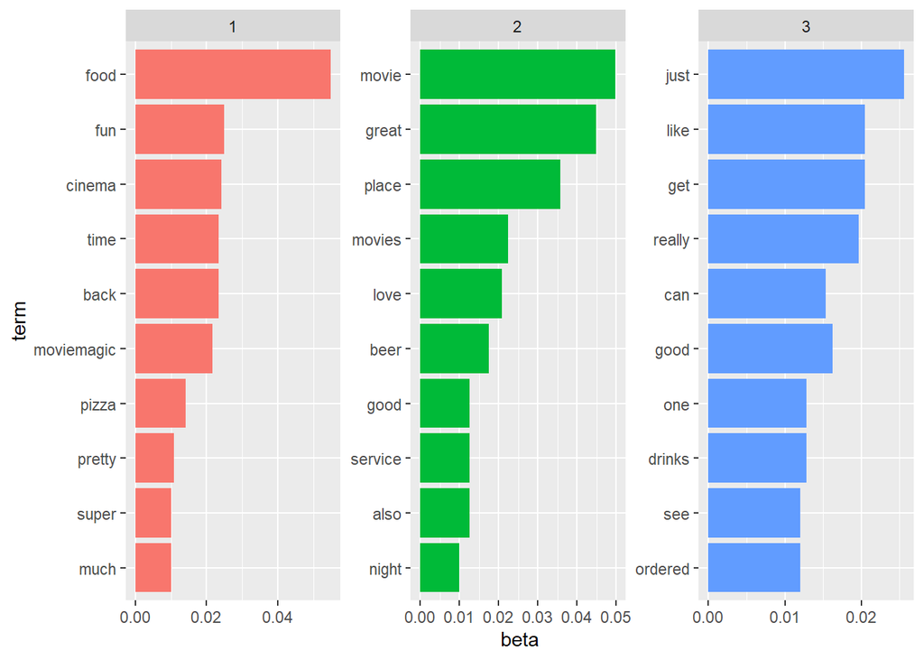

```r
## Topic model LDA

reviews_LDA <- read.csv(url("http://data.mishra.us/files/project_reviews.csv"))

LDA_corpus <- VCorpus(VectorSource(reviews_LDA$text)) #create corpus

#Preprocessing

LDA_corpus <- tm_map(LDA_corpus, content_transformer(tolower)) # covert all to lower case else same word as lower and uppercase will classified as different
LDA_corpus <- tm_map(LDA_corpus, removeWords, stopwords(kind="en")) # remove stop words
func_Space <- content_transformer(function(x, pattern) gsub(pattern, " ", x)) # a function to clean /,@,\\,|
LDA_corpus <- tm_map(LDA_corpus, func_Space, "/|@|\\|")
LDA_corpus <- tm_map(LDA_corpus, stripWhitespace) # remove white space
LDA_corpus <- tm_map(LDA_corpus, removeNumbers) # remove numeric values
LDA_corpus <- tm_map(LDA_corpus, removePunctuation) # remove punctuation


LDA_dtm <- DocumentTermMatrix(LDA_corpus) #create a DTM


rowTotals <- apply(LDA_dtm , 1, sum) #sum of words
LDA_dtm   <- LDA_dtm [rowTotals> 0, ] # removed rows with no words

set.seed(123)
lda_topic <- LDA(LDA_dtm, k = 3, method = "Gibbs", control = NULL) # 3 LDA topics
LDA_topic_model <- tidy(lda_topic, matrix = "beta")

top_terms <- LDA_topic_model %>%
  group_by(topic) %>%
  top_n(10, beta) %>% # 10 terms
  ungroup() %>%
  arrange(topic, -beta)

top_terms %>%
  mutate(term = reorder(term, beta)) %>%
  ggplot(aes(term, beta, fill = factor(topic))) +
  geom_col(show.legend = FALSE) +
  facet_wrap(~ topic, scales = "free") +
  coord_flip()
```

```r
# perplexity calculation - change k = values
lda <- LDA(LDA_dtm, k = 2, control = NULL)
perplexity(lda)
```

```
## [1] 498.9659
```

## Experimental Design

Yes, a causal experiment can be performed. We would propose a 2x3 A/B Test with Loyalty Membership as one dimension and which ad was previewed before the movie as the second dimension. The 3 treatments for the ad would be 1) ad targeted using words from Group 1 LDA, 2) ad targeted using words from Group 2 LDA 3) no pre-movie ad. Every movie ticket would have an included discount for $1 off concessions with a QR code which would be scanned and allow us to determine which pre-movie ad treatment they received. Use of the coupon qualifies you to be counted in the study. The outcome variable would be the amount spent on concessions. We would want to analyze the data to determine per transaction average, per showing proportion of people that made a concession purchase, per day aggregate total concession sales, as well as comparing the results of all transactions where a ticket was scanned.

## Conclusions and Recommendations